# AI ML PBL

**APPLICANT PROFILING** In this step, the dataset is inspected to understand its structure, features, and target variable. This helps in selecting the most relevant attributes for model training and ensures that the data is ready for further preprocessing and analysis.

```python
import pandas as pd
import seaborn as sns
import matplotlib.pyplot as plt
import numpy as np
```

```python
df=pd.read_csv("loan.csv")
df.head(10)
```

|  | ApplicationDate | Age | AnnualIncome | CreditScore | EmploymentStatus | EducationLevel | Experience | LoanAmount | LoanDuration | MaritalStatus | ... | MonthlyIncome | UtilityBillsPaymentHistory | JobTenure | NetWorth | BaseInterestRate | InterestRate | MonthlyLoanPayment | TotalDebtToIncomeRatio | LoanApproved | RiskScore |
| --- | --- | --- | --- | --- | --- | --- | --- | --- | --- | --- | --- | --- | --- | --- | --- | --- | --- | --- | --- | --- | --- |
| 0 | 2018-01-01 | 45 | 39948 | 617 | Employed | Master | 22 | 13152 | 48 | Married | ... | 3329.000000 | 0.724972 | 11 | 126928 | 0.199652 | 0.227590 | 419.805992 | 0.181077 | 0 | 49.0 |
| 1 | 2018-01-02 | 38 | 39709 | 628 | Employed | Associate | 15 | 26045 | 48 | Single | ... | 3309.083333 | 0.935132 | 3 | 43609 | 0.207045 | 0.201077 | 794.054238 | 0.389852 | 0 | 52.0 |
| 2 | 2018-01-03 | 47 | 40724 | 570 | Employed | Bachelor | 26 | 17627 | 36 | Married | ... | 3393.666667 | 0.872241 | 6 | 5205 | 0.217627 | 0.212548 | 666.406688 | 0.462157 | 0 | 52.0 |
| 3 | 2018-01-04 | 58 | 69084 | 545 | Employed | High School | 34 | 37898 | 96 | Single | ... | 5757.000000 | 0.896155 | 5 | 99452 | 0.300398 | 0.300911 | 1047.506980 | 0.313098 | 0 | 54.0 |
| 4 | 2018-01-05 | 37 | 103264 | 594 | Employed | Associate | 17 | 9184 | 36 | Married | ... | 8605.333333 | 0.941369 | 5 | 227019 | 0.197184 | 0.175990 | 330.179140 | 0.070210 | 1 | 36.0 |
| 5 | 2018-01-06 | 37 | 178310 | 626 | Self-Employed | Master | 16 | 15433 | 72 | Married | ... | 14859.166667 | 0.756079 | 5 | 27071 | 0.217433 | 0.217601 | 385.577074 | 0.075211 | 1 | 44.0 |
| 6 | 2018-01-07 | 58 | 51250 | 564 | Employed | High School | 39 | 12741 | 48 | Married | ... | 4270.833333 | 0.884275 | 5 | 21730 | 0.225741 | 0.205271 | 391.300352 | 0.170529 | 0 | 50.0 |
| 7 | 2018-01-08 | 49 | 97345 | 516 | Employed | High School | 23 | 19634 | 12 | Divorced | ... | 8112.083333 | 0.933492 | 5 | 38621 | 0.226634 | 0.209113 | 1827.360055 | 0.260767 | 1 | 42.4 |
| 8 | 2018-01-09 | 34 | 116841 | 603 | Employed | Bachelor | 12 | 55353 | 60 | Divorced | ... | 9736.750000 | 0.728397 | 3 | 7711 | 0.258853 | 0.291539 | 1762.199026 | 0.246509 | 0 | 61.0 |
| 9 | 2018-01-10 | 46 | 40615 | 612 | Employed | Associate | 19 | 25443 | 12 | Married | ... | 3384.583333 | 0.615323 | 3 | 116812 | 0.184443 | 0.197271 | 2353.577424 | 0.903384 | 0 | 53.0 |

10 rows × 36 columns

```python
df.describe()
```

|  | Age | AnnualIncome | CreditScore | Experience | LoanAmount | LoanDuration | NumberOfDependents | MonthlyDebtPayments | CreditCardUtilizationRate | NumberOfOpenCreditLines | ... | MonthlyIncome | UtilityBillsPaymentHistory | JobTenure | NetWorth | BaseInterestRate | InterestRate | MonthlyLoanPayment | TotalDebtToIncomeRatio | LoanApproved | RiskScore |
| --- | --- | --- | --- | --- | --- | --- | --- | --- | --- | --- | --- | --- | --- | --- | --- | --- | --- | --- | --- | --- | --- |
| count | 20000.000000 | 20000.000000 | 20000.000000 | 20000.000000 | 20000.000000 | 20000.000000 | 20000.000000 | 20000.000000 | 20000.000000 | 20000.000000 | ... | 20000.000000 | 20000.000000 | 20000.000000 | 2.000000e+04 | 20000.000000 | 20000.000000 | 20000.000000 | 20000.000000 | 20000.000000 | 20000.000000 |
| mean | 39.752600 | 59161.473550 | 571.612400 | 17.522750 | 24882.867800 | 54.057000 | 1.517300 | 454.292700 | 0.286381 | 3.023350 | ... | 4891.715521 | 0.799918 | 5.002650 | 7.229432e+04 | 0.239124 | 0.239110 | 911.607052 | 0.402182 | 0.239000 | 50.766780 |
| std | 11.622713 | 40350.845168 | 50.997358 | 11.316836 | 13427.421217 | 24.664857 | 1.386325 | 240.507609 | 0.159793 | 1.736161 | ... | 3296.771598 | 0.120665 | 2.236804 | 1.179200e+05 | 0.035509 | 0.042205 | 674.583473 | 0.338924 | 0.426483 | 7.778262 |
| min | 18.000000 | 15000.000000 | 343.000000 | 0.000000 | 3674.000000 | 12.000000 | 0.000000 | 50.000000 | 0.000974 | 0.000000 | ... | 1250.000000 | 0.259203 | 0.000000 | 1.000000e+03 | 0.130101 | 0.113310 | 97.030193 | 0.016043 | 0.000000 | 28.800000 |
| 25% | 32.000000 | 31679.000000 | 540.000000 | 9.000000 | 15575.000000 | 36.000000 | 0.000000 | 286.000000 | 0.160794 | 2.000000 | ... | 2629.583333 | 0.727379 | 3.000000 | 8.734750e+03 | 0.213889 | 0.209142 | 493.763700 | 0.179693 | 0.000000 | 46.000000 |
| 50% | 40.000000 | 48566.000000 | 578.000000 | 17.000000 | 21914.500000 | 48.000000 | 1.000000 | 402.000000 | 0.266673 | 3.000000 | ... | 4034.750000 | 0.820962 | 5.000000 | 3.285550e+04 | 0.236157 | 0.235390 | 728.511452 | 0.302711 | 0.000000 | 52.000000 |
| 75% | 48.000000 | 74391.000000 | 609.000000 | 25.000000 | 30835.000000 | 72.000000 | 2.000000 | 564.000000 | 0.390634 | 4.000000 | ... | 6163.000000 | 0.892333 | 6.000000 | 8.882550e+04 | 0.261533 | 0.265532 | 1112.770759 | 0.509214 | 0.000000 | 56.000000 |
| max | 80.000000 | 485341.000000 | 712.000000 | 61.000000 | 184732.000000 | 120.000000 | 5.000000 | 2919.000000 | 0.917380 | 13.000000 | ... | 25000.000000 | 0.999433 | 16.000000 | 2.603208e+06 | 0.405029 | 0.446787 | 10892.629520 | 4.647657 | 1.000000 | 84.000000 |

8 rows × 30 columns

```python
df.info()
```

```
<class 'pandas.core.frame.DataFrame'>
RangeIndex: 20000 entries, 0 to 19999
Data columns (total 36 columns):
 #   Column                      Non-Null Count  Dtype
---  ------                      --------------  -----
 0   ApplicationDate             20000 non-null  object
 1   Age                         20000 non-null  int64
 2   AnnualIncome                20000 non-null  int64
 3   CreditScore                 20000 non-null  int64
 4   EmploymentStatus            20000 non-null  object
 5   EducationLevel              20000 non-null  object
 6   Experience                  20000 non-null  int64
 7   LoanAmount                  20000 non-null  int64
 8   LoanDuration                20000 non-null  int64
 9   MaritalStatus               20000 non-null  object
```

[output cut: 28 more lines]

```python
df['LoanApproved'].value_counts()
```

```
LoanApproved
0    15220
1     4780
Name: count, dtype: int64
```

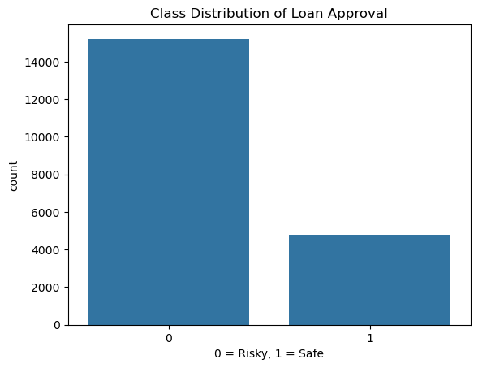

```python
sns.countplot(x=df["LoanApproved"],data=df)
plt.xlabel("0 = Risky, 1 = Safe")
plt.title("Class Distribution of Loan Approval")
plt.show()
```

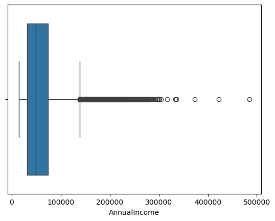

```python
sns.boxplot(x=df['AnnualIncome'])
plt.show()
```

```python
Q1 = df['AnnualIncome'].quantile(0.25)
Q3 = df['AnnualIncome'].quantile(0.75)
IQR = Q3 - Q1
lower = Q1 - 1.5 * IQR
upper = Q3 + 1.5 * IQR
print(lower, upper)
df['AnnualIncome'] = df['AnnualIncome'].clip(lower, upper)
```

```
-32389.0 138459.0
```

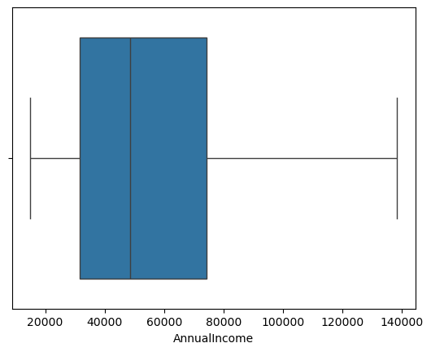

```python
sns.boxplot(x=df['AnnualIncome'])
plt.show()
```

**DATA BALANCING** Data balancing is the process of adjusting the class distribution in a dataset to ensure that all classes are represented equally, preventing bias in machine learning models.

```python
minority = df[df['LoanApproved'] == 1]
# Create variations
minority_aug = minority.copy()
minority_aug['AnnualIncome'] *= (1 + np.random.normal(0, 0.05, len(minority)))
# Merge
df_final = pd.concat([df, minority_aug])
df_final['LoanApproved'].value_counts()
```

```
LoanApproved
0    15220
1     9560
Name: count, dtype: int64
```

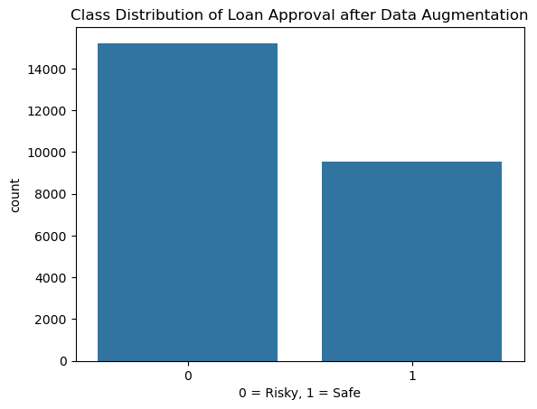

```python
sns.countplot(x=df_final["LoanApproved"],data=df_final)
plt.xlabel("0 = Risky, 1 = Safe")
plt.title("Class Distribution of Loan Approval after Data Augmentation")
plt.show()
```

```python
from sklearn.utils import resample
# Step 1: Separate classes
df_majority = df[df['LoanApproved'] == 0]
df_minority = df[df['LoanApproved'] == 1]
# Step 2: Upsample minority
df_minority_upsampled = resample(df_minority,replace=True,n_samples=len(df_majority),random_state=42)
# Step 3: Combine both
df_balanced = pd.concat([df_majority, df_minority_upsampled])
# Step 4: Shuffle (important)
df_balanced = df_balanced.sample(frac=1, random_state=42).reset_index(drop=True)
# Step 5: Check result
print(df_balanced['LoanApproved'].value_counts())
```

```
LoanApproved
0    15220
1    15220
Name: count, dtype: int64
```

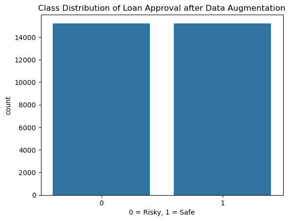

```python
sns.countplot(x=df_balanced["LoanApproved"],data=df_balanced)
plt.xlabel("0 = Risky, 1 = Safe")
plt.title("Class Distribution of Loan Approval after Data Augmentation")
plt.show()
```

```python
X = df[['CreditScore', 'AnnualIncome', 'DebtToIncomeRatio']]
y = df['LoanApproved']
from sklearn.model_selection import train_test_split
X_train, X_test, y_train, y_test = train_test_split(X, y, test_size=0.2, random_state=42)
from sklearn.preprocessing import StandardScaler
scaler = StandardScaler()
X_train = scaler.fit_transform(X_train)
X_test = scaler.transform(X_test)
```

## Logistic Regression

```python
from sklearn.metrics import classification_report, confusion_matrix, accuracy_score, precision_score, f1_score, recall_score
from sklearn.model_selection import GridSearchCV
from sklearn.linear_model import LogisticRegression
model = LogisticRegression()
param_grid = {'C': [0.01, 0.1, 1, 10],'penalty': ['l2'],'solver': ['lbfgs']}
grid = GridSearchCV(model, param_grid, cv=5, scoring='f1')
grid.fit(X_train, y_train)
best_model = grid.best_estimator_
print("Best Parameters:", grid.best_params_)
# Prediction
y_pred = best_model.predict(X_test)
```

```
Best Parameters: {'C': 1, 'penalty': 'l2', 'solver': 'lbfgs'}
```

## Hyperparameter Tuning

Hyperparameter tuning was performed using GridSearchCV to find the optimal parameters for the Logistic Regression model. Different values of the regularization parameter were tested, and the best combination was selected based on F1-score to improve model performance.

```python
print("Accuracy:", accuracy_score(y_test, y_pred))
print("Precision:", precision_score(y_test, y_pred))
print("F1 Score:", f1_score(y_test, y_pred))
print("Recall Score:", recall_score(y_test, y_pred))
```

```
Accuracy: 0.841
Precision: 0.7813884785819794
F1 Score: 0.6245572609208973
Recall Score: 0.52015732546706
```

## Decision Tree

```python
from sklearn.tree import DecisionTreeClassifier
dt = DecisionTreeClassifier()
dt.fit(X_train, y_train)
y_pred_dt = dt.predict(X_test)
```

```python
print("Accuracy:", accuracy_score(y_test, y_pred_dt))
print("Precision:", precision_score(y_test, y_pred_dt))
print("F1 Score:", f1_score(y_test, y_pred_dt))
print("Recall Score:", recall_score(y_test, y_pred_dt))
```

```
Accuracy: 0.769
Precision: 0.5468277945619335
F1 Score: 0.5402985074626866
Recall Score: 0.5339233038348082
```

## Random Forest

```python
from sklearn.ensemble import RandomForestClassifier
rf = RandomForestClassifier()
rf.fit(X_train, y_train)
y_pred_rf = rf.predict(X_test)
```

```python
print("Accuracy:", accuracy_score(y_test, y_pred_rf))
print("Precision:", precision_score(y_test, y_pred_rf))
print("F1 Score:", f1_score(y_test, y_pred_rf))
print("Recall Score:", recall_score(y_test, y_pred_rf))
```

```
Accuracy: 0.828
Precision: 0.7184594953519257
F1 Score: 0.6112994350282486
Recall Score: 0.5319567354965585
```

```python
import joblib
joblib.dump(rf, "model.pkl")
joblib.dump(scaler, "scaler.pkl")
print("Model and scaler saved successfully!")
```

```
Model and scaler saved successfully!
```

## KNN

```python
from sklearn.neighbors import KNeighborsClassifier
knn = KNeighborsClassifier()
knn.fit(X_train, y_train)
y_pred_knn = knn.predict(X_test)
```

```python
print("Accuracy:", accuracy_score(y_test, y_pred_knn))
print("Precision:", precision_score(y_test, y_pred_knn))
print("F1 Score:", f1_score(y_test, y_pred_knn))
print("Recall Score:", recall_score(y_test, y_pred_knn))
```

```
Accuracy: 0.81425
Precision: 0.6670731707317074
F1 Score: 0.5955362003266195
Recall Score: 0.5378564405113078
```